# Homework 2

Jade Butler

2021-10-28

```r
library(tidyverse)
library(openintro)
library(rmarkdown)
```

### Problem 1

#### a)

Mean A: 8, Mean B: 8.78, Mean B is larger than mean A. SD A: 3.39, SD B: 4.92, the standard deviation of B is larger than that of A

#### b)

Mean A: 5, Mean B: 25, Mean B is larger than mean A. SD A: 3.42, SD B: 3.42, even though their range is completely different their SD is the same meaning the dispersion of data is equal.

#### c)

Median A: 6, Median B: 7, median B is larger than median A. IQR A: 4, IQR B: 4.5, IQR of B is larger meaning the middle data points are more spread out.

#### d)

Median A: 6, Median B: 6, their median is equal. IQR A: 4, IQR B: 9.5, the middle data points of B are more spread out than A which demonstrates the larger IQR of dataset B.

### Problem 2

the test is negatively skewed with a left-skewed distribution. The majority of the scores will fall on the right side of the distribution. Also, the distribution on the scores of the test is not symmetric.

### Problem 3

In this case, the mean is greater than the median (Median:100, Mean: 190), the shape of this distribution is right skewed.

### Problem 4

#### a)

```r
EduLvl <- read.csv("GallupByEd.csv")
PartyPref <- read.csv("GallupByPI.csv")
EduLvl$Education <- factor(EduLvl$Education, level=c("College Grad", "Some College", "HS Grad"))
PartyPref$PartyID <- factor(PartyPref$PartyID)
```

#### b)

```r
EduLvl %>%
  count(Education,Response)
```

```
##       Education Response   n
## 1  College Grad        1 205
## 2  College Grad        2 127
## 3  College Grad        3  22
## 4  College Grad        4   4
## 5  Some College        1 132
## 6  Some College        2 131
## 7  Some College        3  17
## 8  Some College        4   4
## 9          <NA>        1 170
## 10         <NA>        2 163
## 11         <NA>        3  13
## 12         <NA>        4  19
```

```r
PartyPref %>%
  count(PartyID,Response)
```

```
##    PartyID Response   n
## 1        D        1 221
## 2        D        2  80
## 3        D        3  13
## 4        D        4   7
## 5        I        1 221
## 6        I        2 158
## 7        I        3  21
## 8        I        4  15
## 9        R        1  48
## 10       R        2 179
## 11       R        3  16
## 12       R        4   6
```

#### c)

```r
In <- PartyPref %>% filter(PartyID == "I")
Per <- In %>% filter(Response == "4")
P <- 100*(count(Per) / count(PartyPref))
P
```

```
##          n
## 1 1.522843
```

#### d)

```r
CG <- EduLvl %>% filter(Education == "College Grad")
Cgg <- 100*(count(CG) / count(EduLvl))
Cgg
```

```
##          n
## 1 35.55114
```

```r
SC <- EduLvl %>% filter(Education == "Some College")
Scc <- 100*(count(SC) / count(EduLvl))
Scc
```

```
##          n
## 1 28.20258
```

```r
HS <- EduLvl %>% filter(Education == "HS Grad")
Hss <- 100*(count(HS) / count(EduLvl))
Hss
```

```
##   n
## 1 0
```

#### e)

```r
EduLvl %>%
  count(Education,Response) %>%
  mutate(prop = n / sum(n)) %>%
  pivot_wider(id_cols = c(Education, Response, prop),
              names_from = Education, values_from = prop)
```

```
## # A tibble: 4 × 4
##   Response `College Grad` `Some College`   `NA`
##      <int>          <dbl>          <dbl>  <dbl>
## 1        1        0.204          0.131   0.169
## 2        2        0.126          0.130   0.162
## 3        3        0.0218         0.0169  0.0129
## 4        4        0.00397        0.00397 0.0189
```

```r
PartyPref %>%
  count(PartyID,Response) %>%
  mutate(prop = n / sum(n)) %>%
  pivot_wider(id_cols = c(PartyID, Response, prop),
              names_from = PartyID, values_from = prop)
```

```
## # A tibble: 4 × 4
##   Response       D      I       R
##      <int>   <dbl>  <dbl>   <dbl>
## 1        1 0.224   0.224  0.0487
## 2        2 0.0812  0.160  0.182
## 3        3 0.0132  0.0213 0.0162
## 4        4 0.00711 0.0152 0.00609
```

#### f)

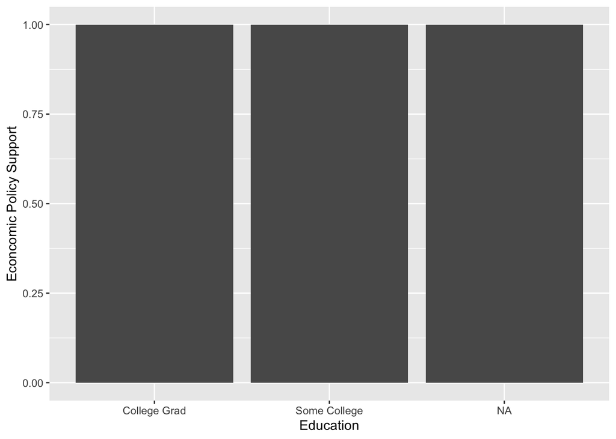

```r
ggplot(EduLvl, aes(x = Education, fill = Response)) +
  geom_bar(position = "fill") +
  ylab("Econcomic Policy Support" )
```

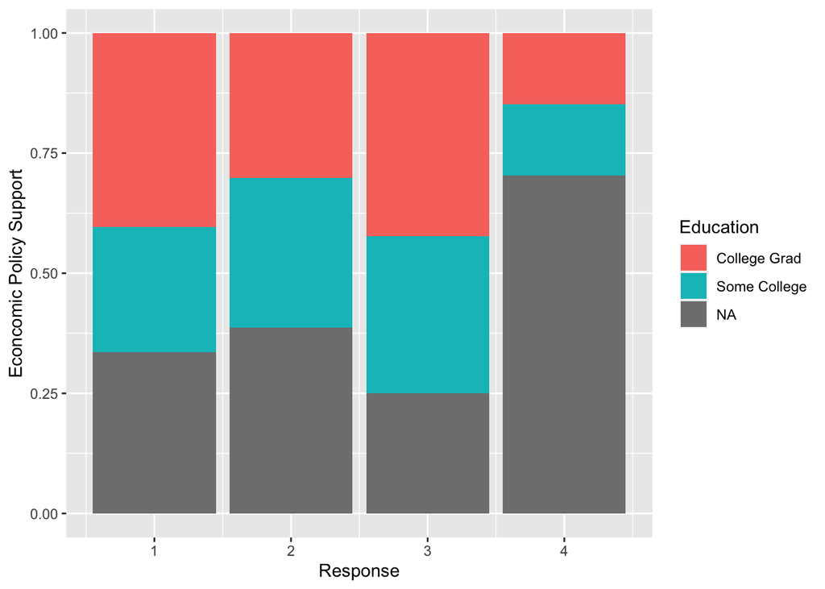

```r
ggplot(EduLvl, aes(x = Response, fill = Education)) +
  geom_bar(position = "fill") +
  ylab("Econcomic Policy Support" )
```

##### The bar plot displaying Education Level vs support of Economic policy (with the fill as the response) doesn’t show much information except that all three levels of education display some support for it just it does not quantify how much. The bar plot with education within the bars themselves gives the viewer much more data but still fails to show the factor variable “HS Grad”.

#### g)

### Problem 5

#### a)

#### b)

#### c)

#### d)

#### e)

#### f)